# Diversity Check_Absent Species

Shaoqian Huang

2026-10-01

## Aims

In this document, we aim to pinpoint the issue of the proposed diversity measure, $\hat{\boldsymbol{\mu}}_B^{\top}\boldsymbol{D}\hat{\boldsymbol{\mu}}_B$, when some species are have extremely low rate of presence or totally absent at certain communities, and explore some potential solutions, including

1. modifying the model by including row effects,
2. modifying the model by putting unimportant species effects to PD/FD measuring into random effects,
3. and explore another measure $\boldsymbol{\mu}_{\text{Rao}}^{\top}\boldsymbol{D}\boldsymbol{\mu}_{\text{Rao}}$ ($\boldsymbol{\mu}_{\text{Rao}} = \boldsymbol{\mu}/\sum \mu_j$).

I present the results into 2 documents, named ‘Model2.html’ for row effect model and ‘Model3.html’ for the model putting part of the species into random effects. Each document investigates both of the measures $\boldsymbol{\mu}_B^{\top}\boldsymbol{D}\boldsymbol{\mu}_B$ and $\boldsymbol{\mu}_{\text{Rao}}^{\top}\boldsymbol{D}\boldsymbol{\mu}_{\text{Rao}}$.

## DGM

### Set up parameters

```r
r <- 128 # sample size in each com
p <- 5 # the number of species
q <- 6 # the number of communities

# Phylogenetics
## Distance matrix
D=matrix(c(0,1,2,3,4,1,0,2,3,4,2,2,0,3,4,3,3,3,0,4,4,4,4,4,0),ncol=5)
colnames(D)=rownames(D)=LETTERS[1:5]
print("--- Distance Matrix ---")
```

```
## [1] "--- Distance Matrix ---"
```

```r
print(D)
```

```
##   A B C D E
## A 0 1 2 3 4
## B 1 0 2 3 4
## C 2 2 0 3 4
## D 3 3 3 0 4
## E 4 4 4 4 0
```

```r
## An orthogonal projection matrix
J <- diag(rep(1, p)) -  1/p * matrix(1, p, p)

# Abundance Setting
## Mean abundance
mu_com5 <- expit(-log(2) + c(log(4), log(1 / 10000), log(4), log(1 / 10000), log(4)))
MeanAund_Absent <- expit(log(1 / 10000))
mu=matrix(c(0.8,MeanAund_Absent,0.8,MeanAund_Absent,0.8,
            MeanAund_Absent,0.8,0.8,MeanAund_Absent,0.8,
            0.8,0.8,MeanAund_Absent,MeanAund_Absent,0.8,
            0.8,0.8,0.8,MeanAund_Absent,MeanAund_Absent,
            mu_com5,
            0.8, MeanAund_Absent, MeanAund_Absent, 0.8, 0.8),
          ncol=6)
rownames(mu)=LETTERS[1:5]
colnames(mu)=1:q
print("--- mu ---")
```

```
## [1] "--- mu ---"
```

```r
mu <- t(mu)
print(mu)
```

```
##            A           B          C           D          E
## 1 0.80000000 9.99900e-05 0.80000000 9.99900e-05 0.80000000
## 2 0.00009999 8.00000e-01 0.80000000 9.99900e-05 0.80000000
## 3 0.80000000 8.00000e-01 0.00009999 9.99900e-05 0.80000000
## 4 0.80000000 8.00000e-01 0.80000000 9.99900e-05 0.00009999
## 5 0.66666667 4.99975e-05 0.66666667 4.99975e-05 0.66666667
## 6 0.80000000 9.99900e-05 0.00009999 8.00000e-01 0.80000000
```

```r
## Logit scale of mean abundance
eta <- logit(mu)
print("--- eta ---")
```

```
## [1] "--- eta ---"
```

```r
print(eta)
```

```
##            A         B          C         D          E
## 1  1.3862944 -9.210340  1.3862944 -9.210340  1.3862944
## 2 -9.2103404  1.386294  1.3862944 -9.210340  1.3862944
## 3  1.3862944  1.386294 -9.2103404 -9.210340  1.3862944
## 4  1.3862944  1.386294  1.3862944 -9.210340 -9.2103404
## 5  0.6931472 -9.903488  0.6931472 -9.903488  0.6931472
## 6  1.3862944 -9.210340 -9.2103404  1.386294  1.3862944
```

```r
## eta_B and mu_eta_B
eta_B <- eta %*% J
mu_eta_B <- expit(eta_B)

## mu_eta
mu_eta <- expit(eta)
```

The design is to mimic the case where certain species are almost totally absent and keeps the PD along coms 1- 6 as before. Specifically, the lower mean abundance 0.2 is changed into an infinitesimal mean abundance; For com 5, we obtain it by subtracting com 1’s overall abundance by $\log(2)$.

### Produce mean abundances with correlations

```r
## Expand mu across sites
mu_site <- mu[rep(c(1 : q), each = r), ]

# Generate u
## Set variance and covariance matrix of u
S <- max(D) - D
mean <- rep(0, p)
sigma <- S

## Generate r * p multivariate normal samples
resi_corr <- rmvnorm(n = r * q, mean = mean, sigma = sigma)

## Linear predictors across sites
eta_u_site <- logit(mu_site) + resi_corr

## Mean abundance matrix with correlations
mu_eta_u_site <- expit(eta_u_site)
```

I set the similarity matrix $S$ as the variance-covariance matrix of $u$, which induces correlations between species abundances.

### Data Generation

```r
# Generate Presence/Absence Data
## Generate Presence/Absence Matrix
abundance <- mu_eta_u_site
abundance[] <- rbinom(length(mu_eta_u_site), size = 1, prob = mu_eta_u_site)

## Create community factor (1:q repeated r times each)
com <- factor(rep(1:q, each=r))

## Combine abundance matrix and community labels into a data frame
Abund <- data.frame(abundance, com)

## Long Format Presence/Absence Data
yX <- reshape(Abund, direction = "long", varying = colnames(abundance),
              v.names = "y", timevar = "sp")

#### Convert species column to factor
yX$sp <- factor(yX$sp)
yX$id <- factor(yX$id)
```

## Modelling

```r
model_id <- params$model

if (model_id == 1) {
  model <- glmmTMB (y ~ com * sp + rr(sp + 0 | id, 2),
                  family = 'binomial',
                  data = yX)
} else if (model_id == 2) {
  model <- glmmTMB (y ~  id + com * sp + rr(sp + 0 | id, 2),
                  family = 'binomial',
                  data = yX)
} else if (model_id == 3) {
  num.eig <- get_num.eig(Methods = 'Method3', NA, D = diag(eigen(J %*% S %*% J)$values[1 : (p -1)]))
  model <- fit_model(type = 'p_mid', matrix_type = 'P_J', rr = TRUE,
                     yX = yX, P_J = eigen(J %*% S %*% J)$vectors,
                     val_num.eig = num.eig, Distribution = 'binomial', null = FALSE, p = p)$fit
}
```

```
## dropping columns from rank-deficient conditional model: com2, com3, com4, com5, com6
```

```r
summary(model)
```

```
##  Family: binomial  ( logit )
## Formula:          y ~ id + com * sp + rr(sp + 0 | id, 2)
## Data: yX
##
##      AIC      BIC   logLik deviance df.resid
##       NA       NA       NA       NA     3039
##
## Random effects:
##
## Conditional model:
##  Groups Name Variance  Std.Dev. Corr
##  id     sp1  1.463e+04 120.953
##         sp2  1.974e+00   1.405   0.85
##         sp3  4.882e+04 220.950  -0.35  0.19
##         sp4  3.111e+00   1.764  -0.67 -0.17  0.93
##         sp5  2.285e+05 477.993  -0.52 -0.89 -0.61 -0.29
## Number of obs: 3840, groups:  id, 768
##
## Conditional model:
##             Estimate Std. Error z value Pr(>|z|)
## (Intercept)    1.627        NaN     NaN      NaN
## id2           11.730        NaN     NaN      NaN
## id3           96.579        NaN     NaN      NaN
## id4           11.730        NaN     NaN      NaN
## id5           -9.208        NaN     NaN      NaN
## id6            8.363        NaN     NaN      NaN
## id7           96.579        NaN     NaN      NaN
## id8           96.579        NaN     NaN      NaN
## id9           -9.208        NaN     NaN      NaN
## id10          -9.208        NaN     NaN      NaN
## id11          96.579        NaN     NaN      NaN
## id12          96.579        NaN     NaN      NaN
## id13           8.363        NaN     NaN      NaN
## id14          96.579        NaN     NaN      NaN
## id15          96.579        NaN     NaN      NaN
## id16          96.579        NaN     NaN      NaN
## id17          -9.208        NaN     NaN      NaN
## id18          96.579        NaN     NaN      NaN
## id19          96.579        NaN     NaN      NaN
## id20          96.579        NaN     NaN      NaN
```

[output cut: 216 more lines]

[output not shown]

## Model-based Diversity Assessment

### Extract fixed and random effects

```r
# Extract Fixed and Random Effects
## Estimates of Fixed Effects plus Random Effects, eta_T_u_hat
eta_T_u_hat <- predict(model,
                   type = "link",
                   re.form = NULL)

### Arrange eta_T_u_hat into a matrix
eta_T_u_hat <- matrix(
  as.numeric(eta_T_u_hat),
  ncol = p,
  byrow = FALSE
)

## Estimate uncertainty of u_hat
uncertain <- simulate_random_effects(model = model, uncertainty = TRUE)
```

### Does $\boldsymbol{\mu}_B^{\top}D\boldsymbol{\mu}_B$ or $\boldsymbol{\mu}_{Rao}^{\top}D\boldsymbol{\mu}_{Rao}$ measure diversity correctly?

```r
# TRUE Diversity
Div_TRUE <- rowSums(mu %*% D * mu)
print("--- TRUE Diversity ---")
```

```
## [1] "--- TRUE Diversity ---"
```

```r
print(Div_TRUE)
```

```
##         1         2         3         4         5         6
## 12.802720 12.802720 11.522880  6.403360  8.890022 14.082720
```

```r
# Model-based diversity
## mu_B
Div_Model <- rowSums(mu_eta_B %*% D * mu_eta_B)
print("--- Model mu_B ---")
```

```
## [1] "--- Model mu_B ---"
```

```r
print(Div_Model)
```

```
##         1         2         3         4         5         6
## 19.493169 19.493169 17.553063  9.789231 19.493169 21.436681
```

```r
## mu_Rao
Div_Model_Rao <- rowSums((mu_eta / apply(mu_eta, 1, sum)) %*% D * (mu_eta / apply(mu_eta, 1, sum)))
print("--- Model mu_Rao ---")
```

```
## [1] "--- Model mu_Rao ---"
```

```r
print(Div_Model_Rao)
```

```
##        1        2        3        4        5        6
## 2.222324 2.222324 2.000167 1.111509 2.222283 2.444509
```

Yes, the results show that both $\boldsymbol{\mu}_B^{\top}\boldsymbol{D}\boldsymbol{\mu}_B$ and $\boldsymbol{\mu}_{\text{Rao}}^{\top}\boldsymbol{D}\boldsymbol{\mu}_{\text{Rao}}$ can measure the exact trend of absolute PD of coms 1 - 6, but only $\boldsymbol{\mu}_B^{\top}\boldsymbol{D}\boldsymbol{\mu}_B$ is totally insensitive to variation in overall abundance.

### Are $\mu_B^{\top}D\mu_B$ or $\hat{\mu}_{Rao}^{\top}D\hat{\mu}_{Rao}$ and their estimators consistent with Rao’s Q and randomized Rao’s Q?

#### Is $\mu_B^{\top}D\mu_B$ or $\hat{\mu}_{Rao}^{\top}D\hat{\mu}_{Rao}$ consistent with Rao’s Q and randomized Rao’s Q?

```r
# Rao
## Rao
Div_Rao <- rowSums((mu/apply(mu, 1, sum)) %*% D * (mu/apply(mu, 1, sum)))
print("--- RaosQ ---")
```

```
## [1] "--- RaosQ ---"
```

```r
print(Div_Rao)
```

```
##        1        2        3        4        5        6
## 2.222324 2.222324 2.000167 1.111509 2.222283 2.444509
```

```r
## Randomized Rao's Q
Div_rand_RaosQ <- randomization(
  abundance = mu,
  DM_phy_func = D
)
print("--- Randomized RaosQ ---")
```

```
## [1] "--- Randomized RaosQ ---"
```

```r
print(Div_rand_RaosQ)
```

```
##           1           2           3           4           5           6
##  0.51289099  0.52483674 -0.04824341 -2.22184545  0.51290320  1.09474490
```

```r
# Model-based Diversity
## mu_B
print("--- Model mu_B ---")
```

```
## [1] "--- Model mu_B ---"
```

```r
print(Div_Model)
```

```
##         1         2         3         4         5         6
## 19.493169 19.493169 17.553063  9.789231 19.493169 21.436681
```

```r
## mu_Rao
print("--- Model mu_Rao ---")
```

```
## [1] "--- Model mu_Rao ---"
```

```r
print(Div_Model_Rao)
```

```
##        1        2        3        4        5        6
## 2.222324 2.222324 2.000167 1.111509 2.222283 2.444509
```

Yes. Both the two measures show the same trend of absolute diversities along coms 1 - 6 with Rao’s Q and randomized Rao’s Q. Furthermore, the results show that $\boldsymbol{\mu}_{\text{Rao}}^{\top}\boldsymbol{D}\boldsymbol{\mu}_{\text{Rao}}$ is completely the same as Rao’s Q.

#### Is $\hat{\mu}_B^{\top}D\hat{\mu}_B$ or $\hat{\mu}_{Rao}^{\top}D\hat{\mu}_{Rao}$ consistent with Rao’s Q and randomized Rao’s Q?

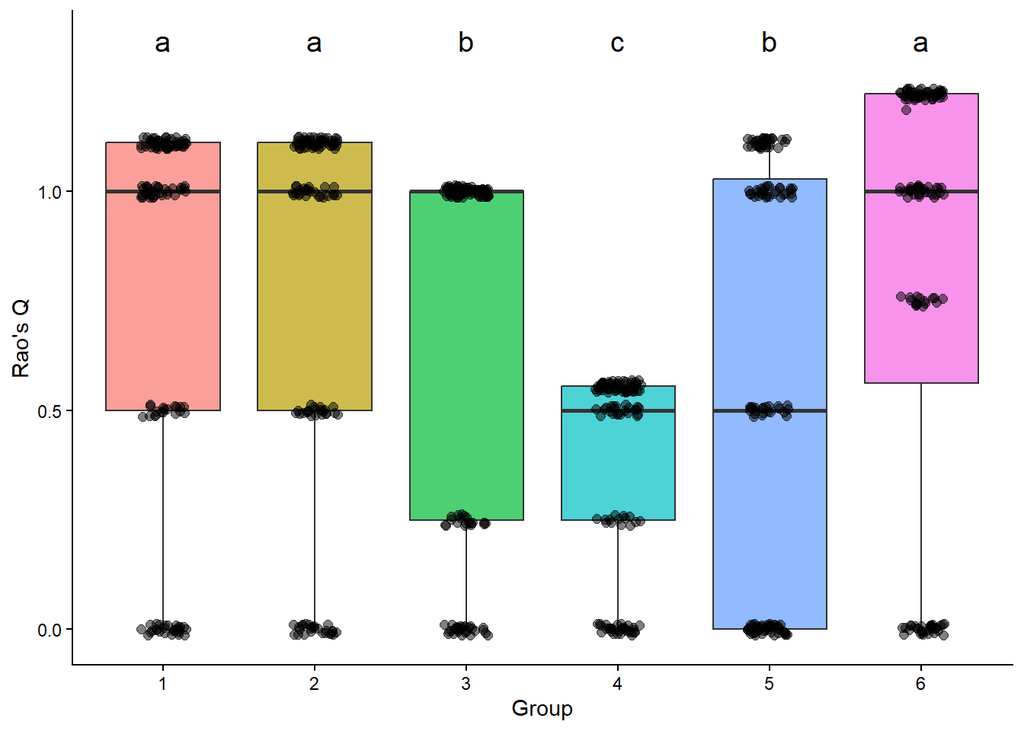

```r
# Produce Boxplot for RaosQ
## Produce boxplot for raosQ
RaosQ <- RaoQ(my.sample = abundance, DM = D)
RaosQ_data <- data.frame(
  group = com,
  value = RaosQ
)
fig_raosQ <- Boxplot(
  data = RaosQ_data,
  group_levels = c(
      "1",
      "2",
      "3",
      "4",
      "5",
      "6"
    ),
    ylab = "Rao's Q")
fig_raosQ
```

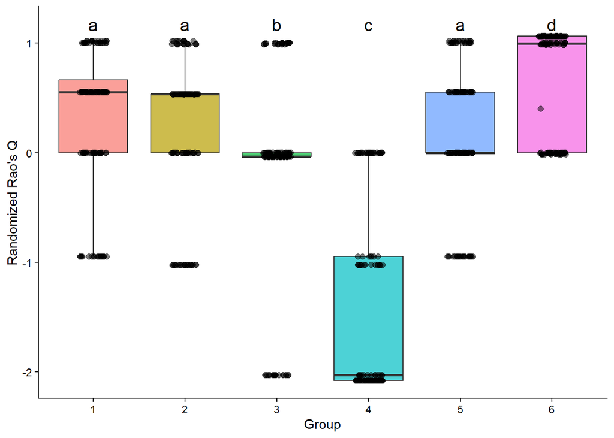

```r
## Produce boxplot for randomized RaosQ
RaosQ_rand <- randomization(
  abundance = abundance,
  DM_phy_func = D
)

### Combine randomized Rao's Q values with community groups.
RaosQ_rand_data <- data.frame(
  group = com,
  value = RaosQ_rand
)

fig1 <- Boxplot(data = RaosQ_rand_data,
                group_levels = c(
       "1",
      "2",
      "3",
      "4",
      "5",
      "6"),
    ylab = "Randomized Rao's Q")
fig1
```

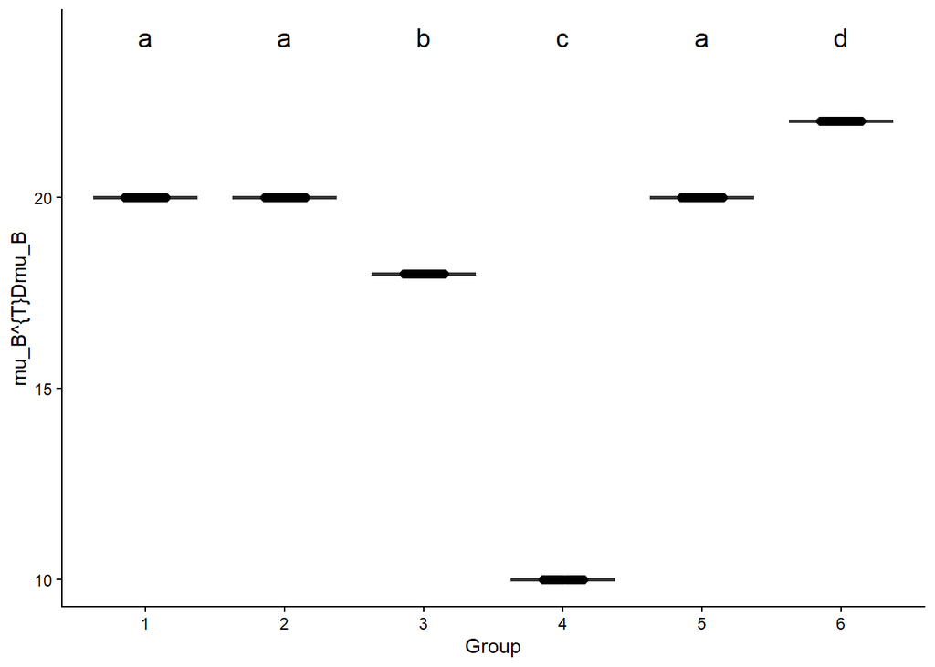

```r
# Produce Boxplot for Model-based Diversity in Each Community
## Model-based diversity assessment based on mu_B
mu_eta_B_u_hat_uncertain <- expit((eta_T_u_hat + uncertain) %*% J)
Div_Model <-  rowSums(mu_eta_B_u_hat_uncertain %*% D * mu_eta_B_u_hat_uncertain)
Div_Model_data <- data.frame(
  group = com,
  value = Div_Model
)
Boxplot(data = Div_Model_data,
        group_levels = c(
          '1',
          '2',
          '3',
          '4',
          '5',
          '6'),
        ylab = "mu_B^{T}Dmu_B"
        )
```

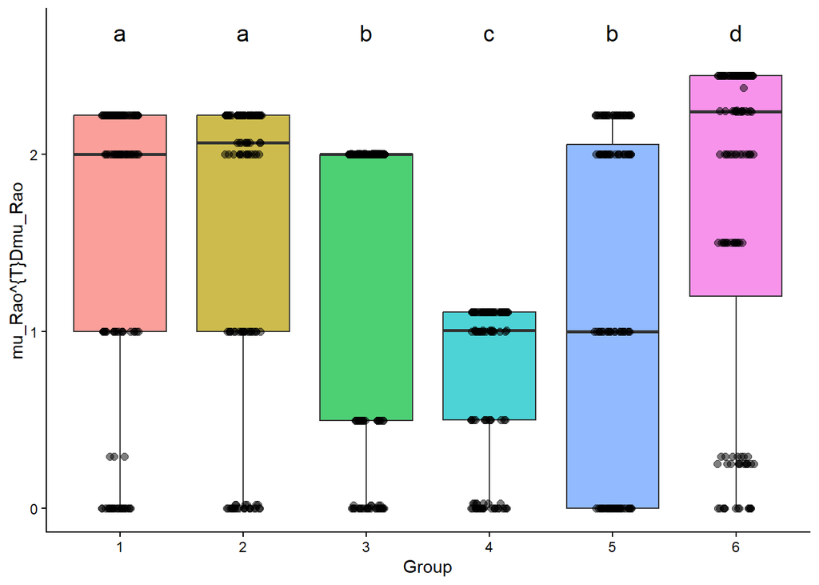

```r
# Model-based diveristy assessnebt based on mu_Rao
mu_eta_u_hat_uncertain <- expit(eta_T_u_hat + uncertain)
Div_Model_Rao <-  rowSums((mu_eta_u_hat_uncertain / apply(mu_eta_u_hat_uncertain, 1, sum)) %*% D * (mu_eta_u_hat_uncertain / apply(mu_eta_u_hat_uncertain, 1, sum)))
Div_Model_Rao_data <- data.frame(
  group = com,
  value = Div_Model_Rao
)
Boxplot(data = Div_Model_Rao_data,
        group_levels = c(
          '1',
          '2',
          '3',
          '4',
          '5',
          '6'),
        ylab = "mu_Rao^{T}Dmu_Rao"
        )
```

1. in terms of $\hat{\boldsymbol{\mu}}_B^{\top}\boldsymbol{D}\hat{\boldsymbol{\mu}}_B$, it is consistent with Randomized Rao’s Q and inconsistent with Rao’s Q. Specifically, the results shows that com 5 has a different variation in Rao’s Q compared with com 1, whereas the variation of com 5 in $\hat{\boldsymbol{\mu}}_B^{\top}\boldsymbol{D}\hat{\boldsymbol{\mu}}_B$ and randomized Rao’s Q is the same as com 1.
2. in terms of $\hat{\boldsymbol{\mu}}_{\text{Rao}}^{\top}\boldsymbol{D}\hat{\boldsymbol{\mu}}_{\text{Rao}}$, it is consistent with Rao’s Q and inconsistent with randomized Rao’s Q. Specifically, the results shows that com 5 has a different variation in Rao’s Q and in $\hat{\boldsymbol{\mu}}_{\text{Rao}}^{\top}\boldsymbol{D}\hat{\boldsymbol{\mu}}_{\text{Rao}}$ compared with com 1, whereas the variation of com 5 in randomized Rao’s Q is the same as com 1.

In conclusion, $\hat{\boldsymbol{\mu}}_B^{\top}\boldsymbol{D}\hat{\boldsymbol{\mu}}_B$ is consistent with randomized Rao’s Q, and $\hat{\boldsymbol{\mu}}_{\text{Rao}}^{\top}\boldsymbol{D}\hat{\boldsymbol{\mu}}_{\text{Rao}}$ is consistent with Rao’s Q.

### Can we visualize projected abundance at $\eta$ scale onto $\boldsymbol{v}_{J1}$ and $\boldsymbol{v}_{J2}$ to show how diversity changes along gradients on a biplot and how the species contributes to diversity within each community?

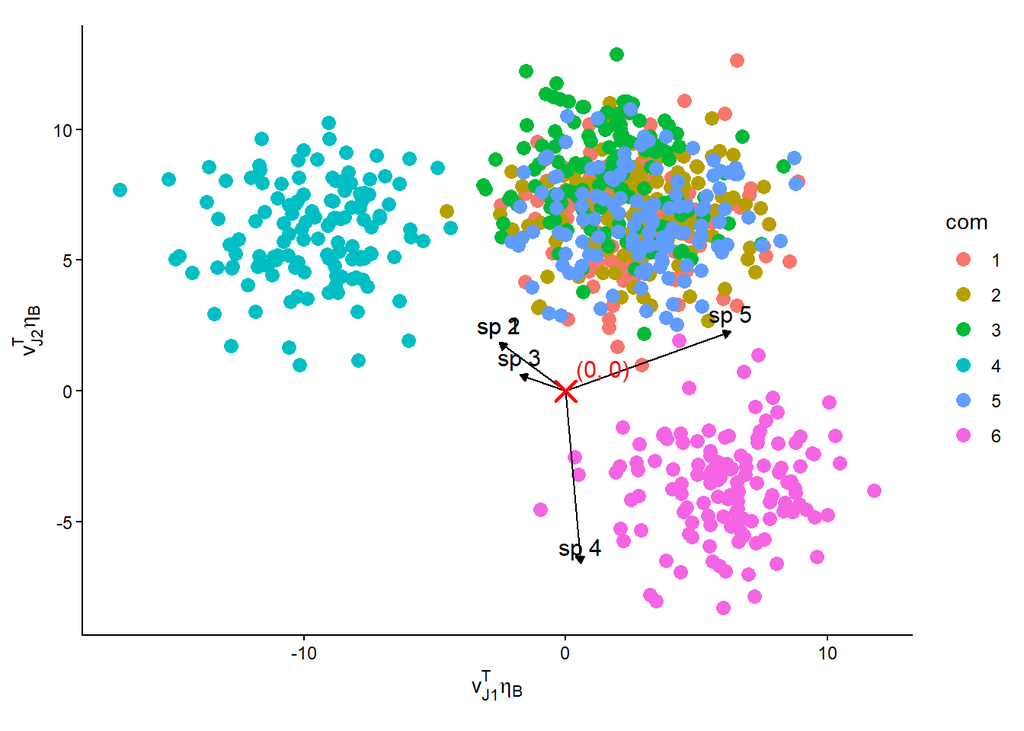

```r
## Produce a biplot based on \eta + u (true parameters)
Biplot(abundance = cbind(com, eta_u_site), P = eigen(J %*% S %*% J)$vectors, plot_labs = labs(
  x = expression(v[J1]^T * eta[B]),
  y = expression(v[J2]^T * eta[B])
), c = 7.5)
```

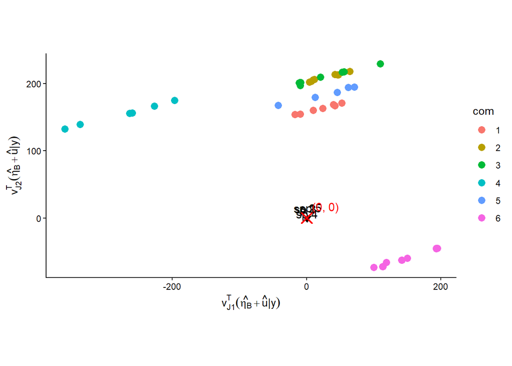

```r
## Produce a biplot based on estimate of \eta_B + u (Estimate \eta_B and u with uncertainty)
eta_T_u_hat_uncertain  <- eta_T_u_hat + uncertain
colnames(eta_T_u_hat_uncertain) <- LETTERS[1:5]
Biplot(abundance = cbind(com, eta_T_u_hat_uncertain), P = eigen(J %*% S %*% J)$vectors, plot_labs = labs(
  x = expression(v[J1]^T * (hat(eta[B]) + hat(u) * "|" * y)),
  y = expression(v[J2]^T * (hat(eta[B]) + hat(u) * "|" * y))
), c = 7.5)
```

The second biplot shows that the model estimates make communities farther away from each other compared with the first biplot based on true values. That may suggest that the model estimates may not be very close to true values.

```r
# Check Model Estimates
eta_u_site_data <- data.frame(
  com = com,
  eta_u_site
)

eta_T_u_hat_data <- data.frame(
  com = com,
  eta_T_u_hat
)
colnames(eta_T_u_hat_data)[-1] <- LETTERS[1:5]

GroupMean_eta_u_site_data <- eta_u_site_data %>%
  group_by(com) %>%
  summarise(
    across(
      everything(),
      ~ mean(.x, na.rm = TRUE)
    )
  )

GroupMean_eta_T_u_hat_data <- eta_T_u_hat_data %>%
  group_by(com) %>%
  summarise(
    across(
      everything(),
      ~ mean(.x, na.rm = TRUE)
    )
  )
print("--- Community average of true values ---")
```

```
## [1] "--- Community average of true values ---"
```

```r
print(GroupMean_eta_u_site_data)
```

```
## # A tibble: 6 × 6
##   com        A      B      C     D      E
##   <fct>  <dbl>  <dbl>  <dbl> <dbl>  <dbl>
## 1 1      1.50   -9.14  1.32  -9.13  1.30
## 2 2     -8.96    1.39  1.64  -9.34  1.57
## 3 3      1.44    1.45 -9.17  -8.88  1.41
## 4 4      1.18    1.42  1.14  -9.25 -9.31
## 5 5      0.740 -10.1   0.552 -9.79  0.619
## 6 6      1.30   -9.16 -9.38   1.47  1.32
```

```r
print("--- Community average of the model estimates ---")
```

```
## [1] "--- Community average of the model estimates ---"
```

```r
print(GroupMean_eta_T_u_hat_data)
```

```
## # A tibble: 6 × 6
##   com        A      B      C      D         E
##   <fct>  <dbl>  <dbl>  <dbl>  <dbl>     <dbl>
## 1 1       35.4 -116.    35.8 -197.    18.0
## 2 2     -122.    29.5   42.4 -250.    17.0
## 3 3       39.4   21.6 -134.  -218.    60.2
## 4 4       29.0   46.7   56.2 -235.  -246.
## 5 5       17.3 -169.    35.8 -247.    -0.0753
## 6 6       31.8  -87.3 -311.    44.2   53.0
```

## Conslusions

Under the simulated presence/absence data set where there are (almost) absent species at some communities, we got problematic estimates of $\boldsymbol{\mu}_B^{\top}\boldsymbol{D}\boldsymbol{\mu}_B$ based on the model containing $\verb|sp : com|$ as fixed effects. We tried three solutions, involving modifying the model and investigating another measure $\boldsymbol{\mu}_{\text{Rao}}^{\top}\boldsymbol{D}\boldsymbol{\mu}_{\text{Rao}}$, and stored all of the results at two documents ‘Model2.html’ and ‘Model3.html’.